# COVID-19 Draft

PhD Dejan Mircetic

2020-April-03

$\alpha$ - version

Initial version: 22.03.2020.

```r
library(readr)
library(forecast)
library(tidyverse)
```

```r
corona <- read_delim("C:/Users/ASUS/Desktop/Corona/corona.txt",
    "\t", escape_double = FALSE, trim_ws = TRUE)
```

Za kreiranje projekcije koriscen je **modifikovani eksponencijalni model**:

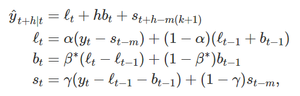

Matematicki model

Prognoza broja obelelih za period od 22.03 do 31.03, odnosno za za **9 narednih dana**, prikazana je na slici ispod.

[figure not shown]

```r
autoplot(prognoza,showgap=FALSE,fcol=2,main="Projekcija obolelih za narednih 9 dana",xlab="Dani u martu",ylab = "Broj obolelih")+
  theme_bw() +
  geom_vline(xintercept = c(5+dim(corona)[1]),col="red")
```

U numerickim vrednostima kretanje broja obolelih moze se ocekivati u sledecim intervalima (scenarijima):

```r
tab <- matrix(NA,ncol=9,nrow=3)
tab[1,] <- round(as.numeric(prognoza$upper[,2]))
tab[2,] <- round(as.numeric(prognoza$mean))
tab[3,] <- round(as.numeric(prognoza$lower[,2]))
colnames(tab) <- c(paste0(23:31, c(rep(".03.", 9))))
rownames(tab) <- c("Najpesimisticniji", "Ocekivani", "Najoptimisticniji")
knitr::kable(tab, digits=2, caption = "Prognoze po danima",align = "c",booktabs = TRUE)
```

```
|                  | 23.03. | 24.03. | 25.03. | 26.03. | 27.03. | 28.03. | 29.03. | 30.03. | 31.03. |
|:-----------------|:------:|:------:|:------:|:------:|:------:|:------:|:------:|:------:|:------:|
|Najpesimisticniji |  288   |  358   |  431   |  509   |  590   |  673   |  759   |  848   |  939   |
|Ocekivani         |  272   |  322   |  373   |  424   |  474   |  525   |  575   |  626   |  676   |
|Najoptimisticniji |  255   |  287   |  315   |  338   |  359   |  376   |  391   |  404   |  414   |
```

**Najpesimisticniji scenario**: 288, 358, 431, 509, 590, 673, 759, 848, 939

**Ocekivani**: 272, 322, 373, 424, 474, 525, 575, 626, 676

**Najoptimisticniji**: 255, 287, 315, 338, 359, 376, 391, 404, 414

# Ispitivanje tacnosti

**2020-April-03**

```r
test <- read_delim("C:/Users/ASUS/Desktop/Corona/Corona_GitHub/Covid-Serbia/testMart.txt", "\t", escape_double = FALSE, trim_ws = TRUE)
test <- ts(test[,4],start = 23)
```

Vizaualni prikaz prognoziranog i ostvarenog stanja!

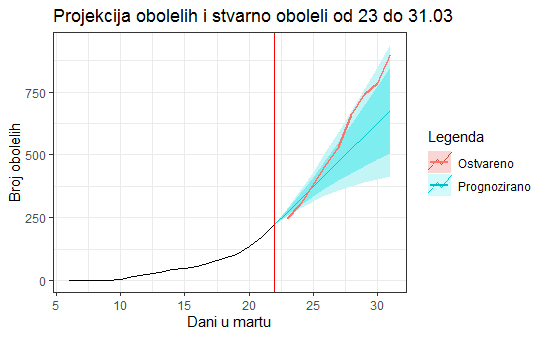

```r
autoplot(covid,main="Projekcija obolelih i stvarno oboleli od 23 do 31.03",xlab="Dani u martu",ylab = "Broj obolelih")+
autolayer(prognoza,showgap=FALSE,fcol=2,series = "Prognozirano")+
  theme_bw() +
  geom_vline(xintercept = c(5+dim(corona)[1]),col="red")+
  autolayer(test,size=1,series = "Ostvareno")+
  guides(colour=guide_legend(title = "Legenda"))
```

Analitički preciznost iznosi:

```r
tacnost <- accuracy(prognoza,test)[2,]
knitr::kable(tacnost, digits=2, caption="Tabela 2. Tacnost prognoziranja.",format = "html",col.names = "vrednosti")
```

```
<table>
<caption>Tabela 2. Tacnost prognoziranja.</caption>
 <thead>
  <tr>
   <th style="text-align:left;">   </th>
   <th style="text-align:right;"> vrednosti </th>
  </tr>
 </thead>
<tbody>
  <tr>
   <td style="text-align:left;"> ME </td>
   <td style="text-align:right;"> 82.13 </td>
  </tr>
  <tr>
   <td style="text-align:left;"> RMSE </td>
   <td style="text-align:right;"> 118.30 </td>
  </tr>
  <tr>
   <td style="text-align:left;"> MAE </td>
   <td style="text-align:right;"> 91.52 </td>
  </tr>
  <tr>
   <td style="text-align:left;"> MPE </td>
   <td style="text-align:right;"> 10.30 </td>
  </tr>
  <tr>
   <td style="text-align:left;"> MAPE </td>
   <td style="text-align:right;"> 13.76 </td>
  </tr>
  <tr>
   <td style="text-align:left;"> MASE </td>
   <td style="text-align:right;"> 6.63 </td>
  </tr>
  <tr>
   <td style="text-align:left;"> ACF1 </td>
   <td style="text-align:right;"> 0.66 </td>
  </tr>
  <tr>
   <td style="text-align:left;"> Theil's U </td>
   <td style="text-align:right;"> 1.01 </td>
  </tr>
</tbody>
</table>
```

Iz prethodne tabele uocava se da je model pravio prosjecnu gresku prognoziranja (MAPE) **13.7641399** %.Jedna od greski koja je koriscena u testiranju tacnosti je i nova MASE greska:

$$\text{MASE} = \text{mean}(|q_{j}|).$$
Mase greska iznosila je **6.6258578**.

# Provjeravanje scenaria sa bias adjusted

Ako smo ranije prilagodili prognoze jer su bile pristrasne za 57.4533226. Na osnvou testa ispod vidimo da se rezidulai ne razlikuju od white noise jer je p vrijednost veca od 0.05.

```
    Ljung-Box test

data:  Residuals from ETS(A,A,N)
Q* = 1.4599, df = 3, p-value = 0.6916

Model df: 4.   Total lags used: 7
```

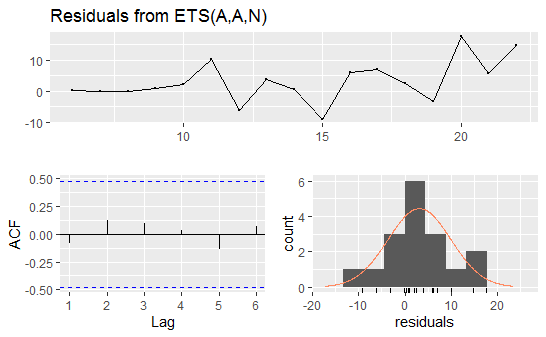

```r
checkresiduals(prognoza)
```

```r
tacnost <- accuracy((prognoza$mean-57),test)
knitr::kable(tacnost, digits=2, caption="Tabela 2. Tacnost prognoziranja.")
```

```
|         |     ME|   RMSE|    MAE|  MPE| MAPE| ACF1| Theil's U|
|:--------|------:|------:|------:|----:|----:|----:|---------:|
|Test set | 139.13| 163.12| 139.13| 22.5| 22.5| 0.66|      1.52|
```

Vidimo da bi na kraju imali vecu MAPE gresku prognoziranja, te da korekcija pristrasnosti nije bila dobra.